# Data Management in R

### Customizing plots

From here, we just **building off** on what we've already specified by adding additional layer/features with an addition `+` and a new `geom` or plotting feature.

```
ggplot(data,aes(x,y)) + geom() +
another_geom() + labels() +
... [anything else we need]
```

To start, let's add a **rug plot** that conveys the univariate distribution for each variable.

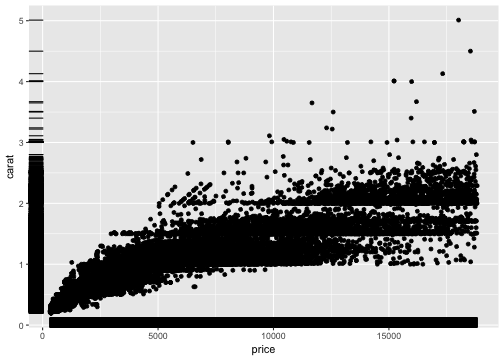

```r
ggplot(data=diamonds,aes(x=price,y=carat)) +
  geom_point() +
  geom_rug()
```

And change the dimensions of the plot using `xlim()` and `ylim()`

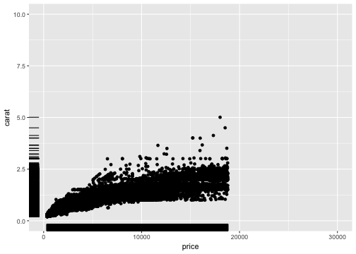

```r
ggplot(data=diamonds,aes(x=price,y=carat)) +
  geom_point() +
  geom_rug() + xlim(0,30000) +
  ylim(0,10)
```

And change the labels using `xlab()`, `ylab()`, and `ggtitle()`

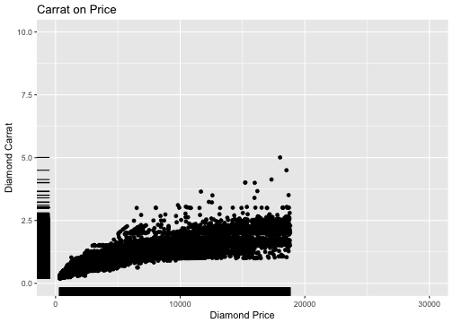

```r
ggplot(data=diamonds,aes(x=price,y=carat)) +
  geom_point() +
  geom_rug() + xlim(0,30000) +
  ylim(0,10) + xlab("Diamond Price") +
  ylab("Diamond Carrat") + ggtitle("Carrat on Price")
```

### Grouping and Visualizing Data

The real power of `ggplot` is the easy by which you can fold in different features of the data either by incorporating it as a size or color variable, or grouping the data along some categorical dimension.

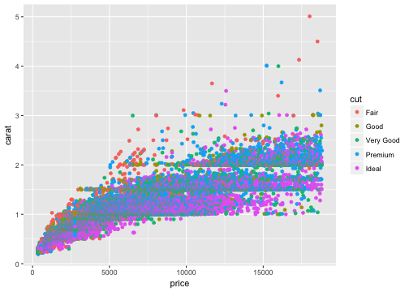

```r
ggplot(data=diamonds,aes(x=price,
                         y=carat,
                         color=cut)) +
  geom_point()
```

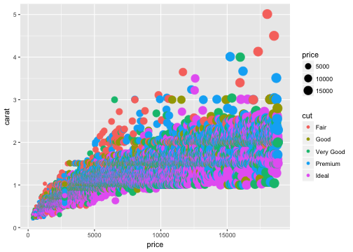

```r
ggplot(data=diamonds,aes(x=price,
                         y=carat,
                         color=cut,
                         size=price)) +
  geom_point()
```

### Customizing Themes

GGPLOT has a number of themes that alter the look and feel of a plot. Moreover, we can customize these themes to suit our needs.

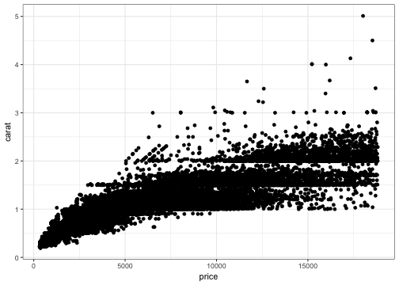

```r
ggplot(data=diamonds,aes(x=price,y=carat)) +
  geom_point() +
  theme_bw() # black and white theme
```

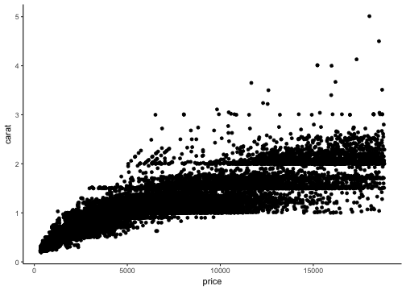

```r
ggplot(data=diamonds,aes(x=price,y=carat)) +
  geom_point() +
  theme_classic() # basic theme
```

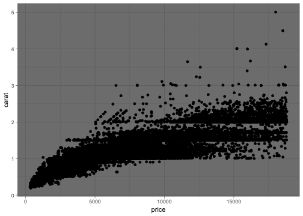

```r
ggplot(data=diamonds,aes(x=price,y=carat)) +
  geom_point() +
  theme_dark() # dark theme
```

### Exploring the variety of plotting options

We've only just touched the surface of what `ggplot` has to offer. As a quick reference and guide, feel free to consult the ggplot [cheatsheet](https://www.rstudio.com/wp-content/uploads/2015/03/ggplot2-cheatsheet.pdf).

In short, `ggplot2` is extremely powerful! The functionality and syntax allow us to easily visualize data, generating compelling summaries of our data.

### Applied Example 1

Let's open the `tidyverse_applications.R` script.

## Modeling Basics

There are a wealth of useful summary operators that are built into `R`.

```r
mean() # Mean
sd() # Standard Deviation
var() # Variance
range() # Range of a variable
min() # Minimum
max() # Maximum
median() # Median
quantile() # Distribution Quantiles
fivenum() # Five Number Summary
colMeans() # Means by Column
rowMeans() # Means by Row
table() # Counts by Category
```

…to name a few!

For the following walk through, let's use the `iris` data.

For more information on the dataset, consult the documentation.

```r
?iris
```

### Summaries

As we've learned the `summary()` function in R, which offers a **concise summary of the distribution of a variable**.

```r
summary(iris$Sepal.Length)
```

```
   Min. 1st Qu.  Median    Mean 3rd Qu.    Max.
  4.300   5.100   5.800   5.843   6.400   7.900
```

The `summary()` function works with a range of different objects (along with `plot()`).

### Summaries

We can also run this on a `data.frame` to get a summary of **each variable**.

```r
summary(iris[,1:3])
```

```
  Sepal.Length    Sepal.Width     Petal.Length
 Min.   :4.300   Min.   :2.000   Min.   :1.000
 1st Qu.:5.100   1st Qu.:2.800   1st Qu.:1.600
 Median :5.800   Median :3.000   Median :4.350
 Mean   :5.843   Mean   :3.057   Mean   :3.758
 3rd Qu.:6.400   3rd Qu.:3.300   3rd Qu.:5.100
 Max.   :7.900   Max.   :4.400   Max.   :6.900
```

### Correlations

We can retrieve the correlation between two variables using the `cor()` base function.

```r
cor(iris$Sepal.Length,iris$Sepal.Width)
```

```
[1] -0.1175698
```

### Correlations

To test if the correlation is statistically significant, we can use the `cor.test()` function.

```r
cor.test(iris$Sepal.Length,iris$Sepal.Width)
```

```
    Pearson's product-moment correlation

data:  iris$Sepal.Length and iris$Sepal.Width
t = -1.4403, df = 148, p-value = 0.1519
alternative hypothesis: true correlation is not equal to 0
95 percent confidence interval:
 -0.27269325  0.04351158
sample estimates:
       cor
-0.1175698
```

### Correlation Matrix

If we have a `data.frame` of numeric values, we can run `cor()` to get a **correlation matrix** – which tells us to what degree all the variables are correlated with every other variable.

```r
iris %>% select(-Species) %>% cor(.)
```

|  | Sepal.Length | Sepal.Width | Petal.Length | Petal.Width |
| --- | --- | --- | --- | --- |
| Sepal.Length | 1 | -0.118 | 0.872 | 0.818 |
| Sepal.Width | -0.118 | 1 | -0.428 | -0.366 |
| Petal.Length | 0.872 | -0.428 | 1 | 0.963 |
| Petal.Width | 0.818 | -0.366 | 0.963 | 1 |

### Visualizing the Correlation Matrix

The package `corrplot` offers a the function `corrplot()` which provides quick visualization of a correlation matrix.

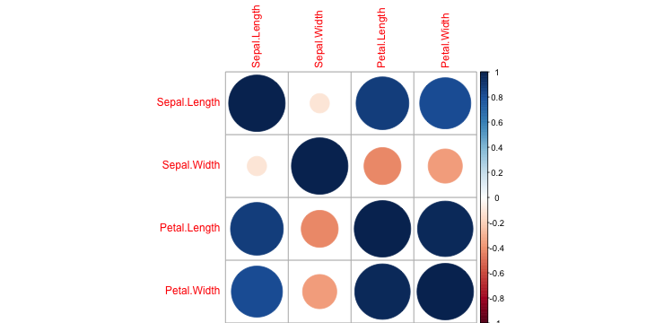

```r
require(corrplot)
iris %>% select(-Species) %>%
  cor(.) %>% corrplot(.)
```

### Group Comparisons

Here let's look at the difference in the `Sepal.Length` between the `setosa` and the `virginica` species.

```r
iris %>%
  filter(Species!="versicolor") %>%
  group_by(Species) %>%
  summarize(mu=mean(Sepal.Length))
```

```
# A tibble: 2 x 2
    Species    mu
     <fctr> <dbl>
1    setosa 5.006
2 virginica 6.588
```

Is that difference statistically meaningful? The `t.test()` function can help us answer this question by performing a difference of means test on our two groups.

```r
# Group 1
g1 <- iris %>% filter(Species=="setosa")
# Group 2
g2 <- iris %>% filter(Species=="virginica")
```

### Two-Sample T-Test

```r
t.test(g1$Sepal.Length,g2$Sepal.Length)
```

```
    Welch Two Sample t-test

data:  g1$Sepal.Length and g2$Sepal.Length
t = -15.386, df = 76.516, p-value < 2.2e-16
alternative hypothesis: true difference in means is not equal to 0
95 percent confidence interval:
 -1.78676 -1.37724
sample estimates:
mean of x mean of y
    5.006     6.588
```

```r
t.test(g1$Sepal.Length,g2$Sepal.Length,
       conf.level = .999)
```

```
    Welch Two Sample t-test

data:  g1$Sepal.Length and g2$Sepal.Length
t = -15.386, df = 76.516, p-value < 2.2e-16
alternative hypothesis: true difference in means is not equal to 0
99.9 percent confidence interval:
 -1.933876 -1.230124
sample estimates:
mean of x mean of y
    5.006     6.588
```

### One-Sample T-Test

Here let's say that we believe the “true” population mean to equal 5.1. How different is our sample mean from this value?

```r
t.test(g1$Sepal.Length,mu=5.1)
```

```
    One Sample t-test

data:  g1$Sepal.Length
t = -1.8857, df = 49, p-value = 0.06527
alternative hypothesis: true mean is not equal to 5.1
95 percent confidence interval:
 4.905824 5.106176
sample estimates:
mean of x
    5.006
```

### Cross Tabulation

A **cross tab** is a concise way of presenting the **joint distributions** of two or more variables. The information is usually displayed as a `table()` (or contingency matrix).

Here we'll look at one of these packages - `gmodels` - for a nice crosstab.

```r
require(gmodels)
```

First, let's generate an indicator variable from the `iris` data which breaks the data up into “big” (Long petal, large Septal )

```r
df <- iris %>%
  mutate(big=as.numeric(Sepal.Length >= 5 & Petal.Length>=1.5))

table(df$big)
```

```
  0   1
 33 117
```

```r
CrossTable(x=df$big,df$Species,
           prop.r = T,prop.c = F,prop.t = F,
           prop.chisq = F,
           chisq = T,format="SPSS")
```

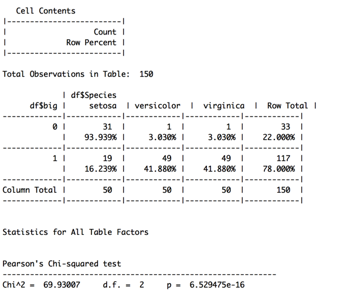

### Linear Model in R

`R` was built for statistics, and to that end, it does its job well. The `lm()` function is a base function in `R` and offers everything one could need when dealing with the linear model.

### Fitting a loess curve

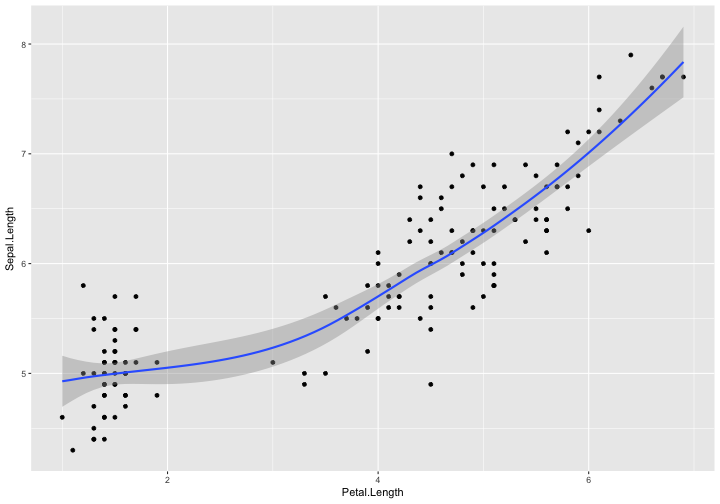

```r
ggplot(iris,aes(Petal.Length,Sepal.Length)) +
  geom_point() +
  geom_smooth(method='loess')
```

### Setting up the lm()

The `lm()` function requires a **formula**, which we specify using a tilde (`~`).

We set this up by saying `y` (outcome) is a function of `x` (predictor): `y ~ x`. We then specify our data object.

```r
lm(Sepal.Length ~ Petal.Length, data=iris)
```

```
Call:
lm(formula = Sepal.Length ~ Petal.Length, data = iris)

Coefficients:
 (Intercept)  Petal.Length
      4.3066        0.4089
```

Much like everything else in `R`. We can allocate the output from a model to an object, which we can then reference later. This object is **loaded** with relevant information produced by `lm()`.

```r
model1 <- lm(Sepal.Length ~ Petal.Length, data=iris)
str(model1)
```

```
List of 12
 $ coefficients : Named num [1:2] 4.307 0.409
  ..- attr(*, "names")= chr [1:2] "(Intercept)" "Petal.Length"
 $ residuals    : Named num [1:150] 0.2209 0.0209 -0.1382 -0.32 0.1209 ...
  ..- attr(*, "names")= chr [1:150] "1" "2" "3" "4" ...
 $ effects      : Named num [1:150] -71.566 8.812 -0.155 -0.337 0.104 ...
  ..- attr(*, "names")= chr [1:150] "(Intercept)" "Petal.Length" "" "" ...
 $ rank         : int 2
 $ fitted.values: Named num [1:150] 4.88 4.88 4.84 4.92 4.88 ...
  ..- attr(*, "names")= chr [1:150] "1" "2" "3" "4" ...
 $ assign       : int [1:2] 0 1
 $ qr           :List of 5
  ..$ qr   : num [1:150, 1:2] -12.2474 0.0816 0.0816 0.0816 0.0816 ...
  .. ..- attr(*, "dimnames")=List of 2
  .. .. ..$ : chr [1:150] "1" "2" "3" "4" ...
  .. .. ..$ : chr [1:2] "(Intercept)" "Petal.Length"
  .. ..- attr(*, "assign")= int [1:2] 0 1
  ..$ qraux: num [1:2] 1.08 1.1
  ..$ pivot: int [1:2] 1 2
  ..$ tol  : num 1e-07
  ..$ rank : int 2
  ..- attr(*, "class")= chr "qr"
 $ df.residual  : int 148
 $ xlevels      : Named list()
 $ call         : language lm(formula = Sepal.Length ~ Petal.Length, data = iris)
 $ terms        :Classes 'terms', 'formula'  language Sepal.Length ~ Petal.Length
  .. ..- attr(*, "variables")= language list(Sepal.Length, Petal.Length)
  .. ..- attr(*, "factors")= int [1:2, 1] 0 1
  .. .. ..- attr(*, "dimnames")=List of 2
  .. .. .. ..$ : chr [1:2] "Sepal.Length" "Petal.Length"
  .. .. .. ..$ : chr "Petal.Length"
  .. ..- attr(*, "term.labels")= chr "Petal.Length"
  .. ..- attr(*, "order")= int 1
  .. ..- attr(*, "intercept")= int 1
  .. ..- attr(*, "response")= int 1
  .. ..- attr(*, ".Environment")=<environment: R_GlobalEnv>
  .. ..- attr(*, "predvars")= language list(Sepal.Length, Petal.Length)
  .. ..- attr(*, "dataClasses")= Named chr [1:2] "numeric" "numeric"
  .. .. ..- attr(*, "names")= chr [1:2] "Sepal.Length" "Petal.Length"
 $ model        :'data.frame':  150 obs. of  2 variables:
  ..$ Sepal.Length: num [1:150] 5.1 4.9 4.7 4.6 5 5.4 4.6 5 4.4 4.9 ...
  ..$ Petal.Length: num [1:150] 1.4 1.4 1.3 1.5 1.4 1.7 1.4 1.5 1.4 1.5 ...
  ..- attr(*, "terms")=Classes 'terms', 'formula'  language Sepal.Length ~ Petal.Length
  .. .. ..- attr(*, "variables")= language list(Sepal.Length, Petal.Length)
  .. .. ..- attr(*, "factors")= int [1:2, 1] 0 1
  .. .. .. ..- attr(*, "dimnames")=List of 2
  .. .. .. .. ..$ : chr [1:2] "Sepal.Length" "Petal.Length"
  .. .. .. .. ..$ : chr "Petal.Length"
  .. .. ..- attr(*, "term.labels")= chr "Petal.Length"
  .. .. ..- attr(*, "order")= int 1
  .. .. ..- attr(*, "intercept")= int 1
  .. .. ..- attr(*, "response")= int 1
  .. .. ..- attr(*, ".Environment")=<environment: R_GlobalEnv>
  .. .. ..- attr(*, "predvars")= language list(Sepal.Length, Petal.Length)
  .. .. ..- attr(*, "dataClasses")= Named chr [1:2] "numeric" "numeric"
  .. .. .. ..- attr(*, "names")= chr [1:2] "Sepal.Length" "Petal.Length"
 - attr(*, "class")= chr "lm"
```

### Assessing output

`lm()` overloads the `plot()` and `summary()` functions to produce graphics specific to the object output.

Specifically, `plot()` will print visual information regarding how well the data conforms to the assumptions that underpin the linear model. The function produces a total of four plots:

1. linearity test,
2. normality assumption test,
3. equal variance test (to check for homoskedasticity)
4. pinpointing influential cases.

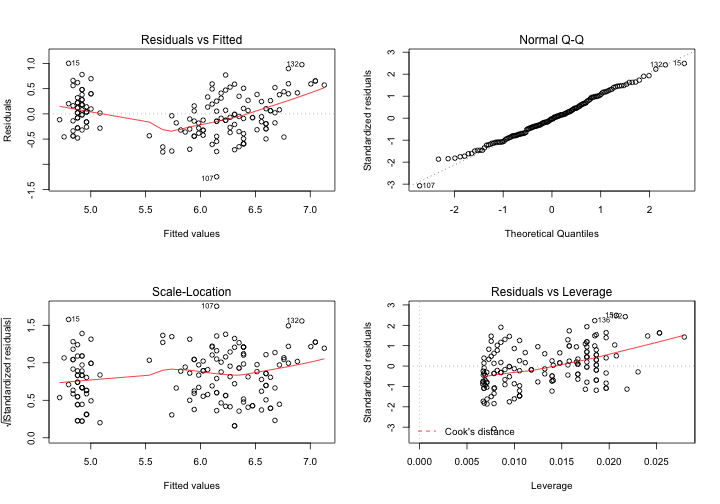

```r
par(mfrow=c(2,2))
plot(model1)
```

We use `summary()` with `lm` objects to get a concise report of our model results.

```r
summary(model1)
```

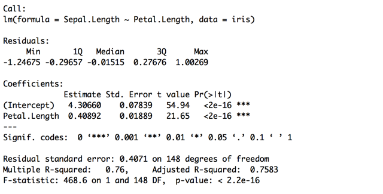

### Auxiliary Extraction Functions

There are a range of functions to help us extract key pieces of information from an `lm` object, such as our

- linear prediction (what the model predicts the value of y to be),
- residuals (how wrong our prediction is from the observed data),
- coefficients (constant and slope),
- goodness of fit (information criteria)

```r
pred <- predict(model1)
as.matrix(pred)
```

```
        [,1]
1   4.879095
2   4.879095
3   4.838202
4   4.919987
5   4.879095
6   5.001771
7   4.879095
8   4.919987
9   4.879095
10  4.919987
11  4.919987
12  4.960879
13  4.879095
14  4.756418
```

[output cut: 136 more lines]

```r
residuals <- resid(model1)
as.matrix(residuals)
```

```
           [,1]
1    0.22090540
2    0.02090540
3   -0.13820238
4   -0.31998683
5    0.12090540
6    0.39822871
7   -0.27909460
8    0.08001317
9   -0.47909460
10  -0.01998683
11   0.48001317
12  -0.16087906
13  -0.07909460
14  -0.45641792
```

[output cut: 136 more lines]

```r
coefficients(model1)
```

```
 (Intercept) Petal.Length
   4.3066034    0.4089223
```

There are also manual ways of extracting the same information.

```r
model1$coefficients
```

```
 (Intercept) Petal.Length
   4.3066034    0.4089223
```

```r
coefs <- model1$coefficients
```

Let's see how well our “best fitting line” did in explaining the relationship.

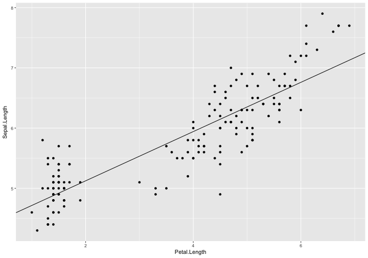

```r
ggplot(iris,aes(Petal.Length,Sepal.Length)) +
  geom_point() +
  geom_abline(intercept =coefs[1],
              slope=coefs[2])
```

### Goodness of Fit

```r
sum1 <- summary(model1)
sum1$r.squared # R Squared
```

```
[1] 0.7599546
```

```r
AIC(model1) # Akaike's Information Criterion
```

```
[1] 160.0404
```

```r
BIC(model1) # Bayesian Information Criterion
```

```
[1] 169.0723
```

### Applied Example 2

Let's open the `basic_modeling.R` script to review some of this and to explore in greater detail different modeling features in `R`.

### Further References

Once again, here are some great resources out there to help you climb the `R` learning curve.

- CodeSchool's [tryr](http://tryr.codeschool.com/) – an interactive game to learn the basics of `R`.
- [swirl](http://swirlstats.com/) – learn `R` from the consol. `Swirl` provides an interactive experience to learning `R` from *within* `R`.
- Some Suggested Readings:
  - [The Art of R Programming](https://www.amazon.com/Art-Programming-Statistical-Software-Design/dp/1593273843/ref=sr_1_1?ie=UTF8&qid=1431630271&sr=8-1&keywords=the+art+of+r+program)
  - [stackoverflow.com](http://stackoverflow.com/)
  - Nearest [Google Browser](https://www.google.com/)

### Thank you!

Please contact me if you have any questions!

**Eric Dunford** | Ph.D. Candidate  
Department of Government and Politics  
University of Maryland, College Park  
edunford@umd.edu  
www.ericdunford.com